# Gradient Boosted Machines: Regression

### Ian J. Douglas

```r
library(gbm)
library(MLmetrics)
library(vip)
library(dplyr)
library(ggplot2)
library(caret)
#remotes::install_github("rstudio/reticulate")
```

```r
library(reticulate)

#Data used:
## Wine Quality for regression:
# https://archive.ics.uci.edu/ml/machine-learning-databases/wine-quality/

# For later use, define a custom ggplot theme for all plots generated in R code:
ggplot2::theme_set(
  theme(
    panel.border = element_rect(color = 'black', fill = NA, size = .9),
    panel.background = element_rect(color = 'black', fill = 'white'),
    panel.grid = element_line(color = 'lightgrey', size = .2),
    plot.background = element_rect(fill = 'white'),
    plot.title = element_text(hjust = .5)
  )
)
```

# 1. Download the datasets

```r
# The red wine dataset:
download.file(
  url = "https://archive.ics.uci.edu/ml/machine-learning-databases/wine-quality/winequality-red.csv",
  destfile = "~/red_wine_qual.csv"
)
# The white wine dataset:
download.file(
  url = "https://archive.ics.uci.edu/ml/machine-learning-databases/wine-quality/winequality-white.csv",
  destfile = "~/white_wine_qual.csv"
)
```

### Read the datasets in to the Rstudio environment

```r
# Here we read in [using read.csv()] both datasets inside of a call to rbind().
# So they will be read in and immediately stacked atop one another into one dataset.
all_wine = rbind(read.csv(
  # Arguments for the first call to read.csv()
  # Enter the file path and name:
  file = "~/red_wine_qual.csv",
  # For some reason, each data point was seperated with a semi-colon in the downloaded data
  sep = ";",
  # For character variables, read them in as character strings, rather than levels of a factor
  # (In case the two data frames we're rbind-ing have different factor levels, rbind would fail)
  stringsAsFactors = F),
  # same for the other dataset:
  read.csv("~/white_wine_qual.csv", sep = ";", stringsAsFactors = F)
) # close the rbind.

# Check out the nature of the dataset
str(all_wine)
```

```
## 'data.frame':    6497 obs. of  12 variables:
##  $ fixed.acidity       : num  7.4 7.8 7.8 11.2 7.4 7.4 7.9 7.3 7.8 7.5 ...
##  $ volatile.acidity    : num  0.7 0.88 0.76 0.28 0.7 0.66 0.6 0.65 0.58 0.5 ...
##  $ citric.acid         : num  0 0 0.04 0.56 0 0 0.06 0 0.02 0.36 ...
##  $ residual.sugar      : num  1.9 2.6 2.3 1.9 1.9 1.8 1.6 1.2 2 6.1 ...
##  $ chlorides           : num  0.076 0.098 0.092 0.075 0.076 0.075 0.069 0.065 0.073 0.071 ...
##  $ free.sulfur.dioxide : num  11 25 15 17 11 13 15 15 9 17 ...
##  $ total.sulfur.dioxide: num  34 67 54 60 34 40 59 21 18 102 ...
##  $ density             : num  0.998 0.997 0.997 0.998 0.998 ...
##  $ pH                  : num  3.51 3.2 3.26 3.16 3.51 3.51 3.3 3.39 3.36 3.35 ...
##  $ sulphates           : num  0.56 0.68 0.65 0.58 0.56 0.56 0.46 0.47 0.57 0.8 ...
##  $ alcohol             : num  9.4 9.8 9.8 9.8 9.4 9.4 9.4 10 9.5 10.5 ...
##  $ quality             : int  5 5 5 6 5 5 5 7 7 5 ...
```

### Explore the data visually

We’ll take a quick look at the distribution of the response variable

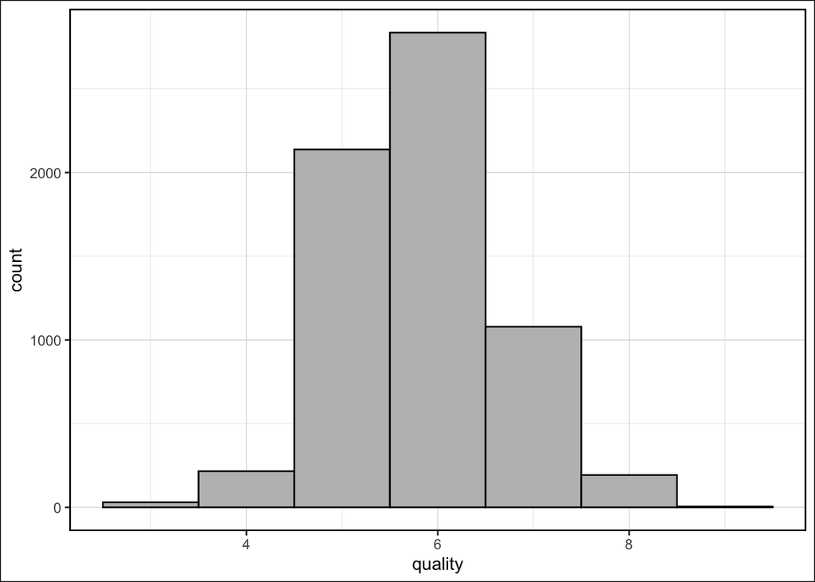

```r
ggplot(all_wine) + # initialize a plotting space
  geom_histogram(aes(x = quality),  # visualize the histogram of the variable "quality"
                 fill = 'grey', color = 'black',
                 # One 'bin' of the histogram per value of quality, since it is actually categorical:
                 bins = n_distinct(all_wine$quality))
```

# 2. Split the data into train and test sets

```r
set.seed(1)
# Use sample() to select random numbers from 1, 2, 3, ... Nrow of the data (row indices)
train.idx <- sample(1:nrow(all_wine), size = nrow(all_wine)*.8)
wine_train <- all_wine[train.idx, ] # use square brackets to subset by these row indices
wine_test <- all_wine[-train.idx, ] # negate the row indexer to select all other rows.

# Save these out as csv files on your computer so that we can later
# access them directly when we run the python code (much later)
write.csv(all_wine, "~/all_wine_quality.csv",
          # don't add a column enumarting the rows:
          row.names = F)
write.csv(wine_train, "~/wine_train.csv", row.names = F)
write.csv(wine_test, "~/wine_test.csv", row.names = F)
```

# 3. Using `gbm` to predict wine quality scores

For now we will hold hyperparameters constant (rather than tuning them). However, the hyperparemeters often tuned for a GBM fit with `gbm::gbm` model are:

1. `shrinkage`: the proportion by which to scale down the new predictions from each sequential tree.
2. `n.minobsinnode`: The minimum size of a terminal leaf or node. Values greater thatn 1 will help attenuate overfitting
3. `interaction.depth`: The number of splits each tree is allowed to make.  
   Other hyperparameters such as `n.trees`,`cv.folds` or `bag.fraction`, usually don’t affect model performance, but can interfere with our ability to find the optimal model if we set a bad value. use `?gbm` for details. *More on hyperparameter tuning below*.

```r
wine_gbm = gbm(
  # Specify the formula for the model in the fomrat: "response ~ predictors"
  formula = quality ~ .,
  # the train data:
  data = wine_train,
  # Specify the assumed distribution of the response variable:
  distribution = 'gaussian',
  # The number of trees to build in total:
  n.trees = 500,
  # The percentage (form 0 to 1) of the residuals from each new tree to increment
  # our cumulative prediction:
  shrinkage = .1, # this is the default
  # The number of samples to randomly sample from previous trees with which
  # to fit subsequent trees:
  bag.fraction = .7,
  # The number of cross validation folds to determine the performance of each tree:
  cv.folds = 5
)
```

### Investigate the performance of the model

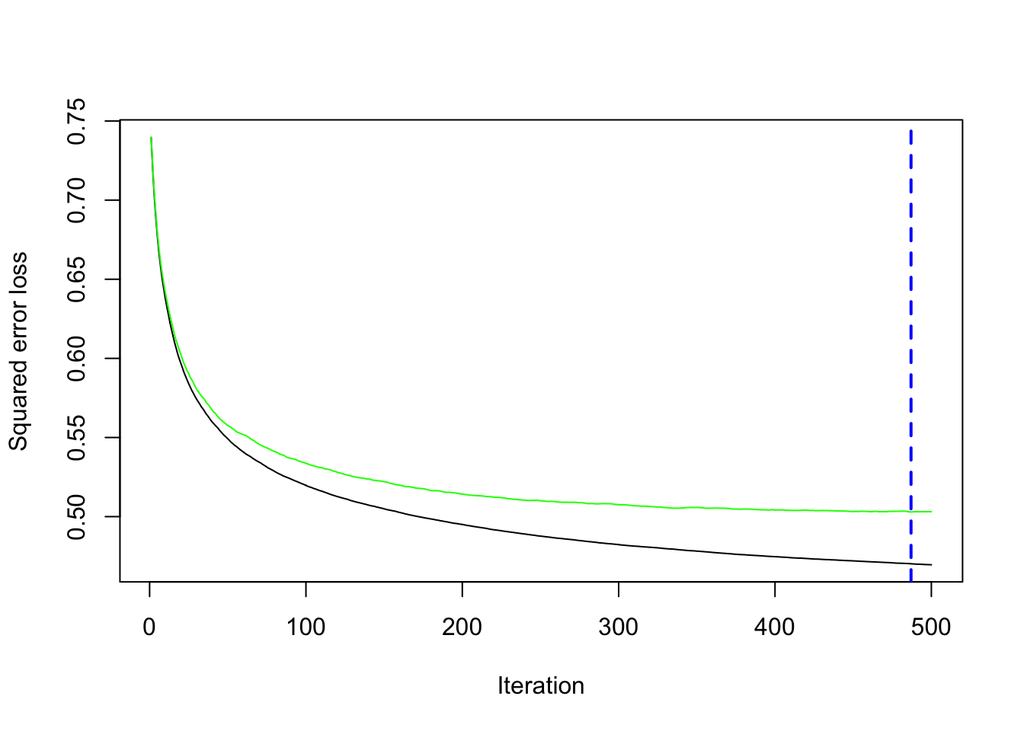

```
## [1] 487
```

```r
# Use gbm's gbm.perf() function
gbm.perf(
  # Supply the model:
  wine_gbm,
  # Compute performance with respect to the cross-validation folds:
  method = 'cv',
  # Set plot.it to T (or TRUE) to visualize the error at each boosting iteration (at each tree):
  plot.it = T
)
```

*Note*: this also printed out a number: 487. That is the boosting iteration, or the number of the tree at which cross-validation error from the 5-fold cross-validation was minimized.

### Calculate the performance on our held-out test set

We’ll use two functions imported from the `MLmetrics` package: `R2_Score` and `MSE`

```r
best_tree = gbm.perf(wine_gbm, plot.it = F, method = 'cv') # now, don't plot it
# Set up a little data frame with a column for the R2 and MSE computed with the test data
# so that it prints out in a clear way.
cross_val_score = data.frame(
  # Here we use functions from MLmetrics package, which take the predicted and true values of
  # the response variable, in order to compute cross-validation scores/metrics of model performance
  R2 = R2_Score(y_pred = predict(wine_gbm, newdata = wine_test, n.trees = best_tree),
                y_true = wine_test$quality),
  MSE = MSE(y_pred = predict(wine_gbm, newdata = wine_test, n.trees = best_tree),
             y_true = wine_test$quality)
)
cross_val_score
```

```
##          R2       MSE
## 1 0.3408006 0.5014888
```

#### Compare it to a linear regression

```r
# Fit model
reg_mod = lm(quality ~ ., data = wine_train)
# Score model with test data:
data.frame(
  R2 = R2_Score(
    y_pred = predict(object = reg_mod, newdata = wine_test),
    y_true = wine_test$quality),
  MSE = MSE(
    y_pred = predict(object = reg_mod, newdata = wine_test),
    y_true = wine_test$quality)
)
```

```
##          R2       MSE
## 1 0.2889758 0.5409148
```

# 4. Compute variable importance

#### A quick primer on (permutation) variable importance.

- Permutation Variable importance works by one-by-one replacing a variable with random noise (by shuffling or *permuting* it), and then quantifying by how much that hurts the model’s performance.
- Larger changes indicate that a given variable is important to the model
- Research shows that these metrics are best computed with the variables in the test set, which avoids introducing a positive-bias/inflation that can result from correlations between predictors (https://threadreaderapp.com/thread/1299146947752796166.html)

### Using `vip::vi_permute()` to compute cross-validated permutation variable importance

```r
# (required by `vip`) Write a function with which to get our predicted values.
# For compatibility, the arguments of the function must be 'object' and 'newdata'
predict_from_best_tree <- function(object, newdata)
{
  predict(object, newdata, n.trees = best_tree)
}
# calculate variable importance
permutation_imp = vi_permute(
  # 1. supply the model (any model)
  object = wine_gbm,
  # 2. Specify the names of the predictors of which we wish to compute the importance
  feature_names = wine_train %>% select(-quality) %>% names,
  # 3. Supply the TEST data, instead of the TRAIN data (a small hack here!)
  train = wine_test,
  # 4. Supply the corresponding response variable
  target = wine_test$quality,
  # 5. The metric with which to assess model performance before/after permutation
  metric = 'mse',
  # 6. define importance as the ratio of true-to-permuted MSE
  type = 'ratio',
  # 7. For stability, permute each variable 100 times.
  nsim = 100,
  keep = T, # for plotting, this needs to be TRUE
  pred_wrapper = predict_from_best_tree # Here we supply our wrapper of predict()
)

# Print the table of variable importances, and the St.Dev from the 100 permutations
permutation_imp
```

```
## # A tibble: 11 x 3
##    Variable             Importance   StDev
##    <chr>                     <dbl>   <dbl>
##  1 fixed.acidity              1.01 0.00213
##  2 volatile.acidity           1.15 0.0151
##  3 citric.acid                1.02 0.00586
##  4 residual.sugar             1.06 0.00934
##  5 chlorides                  1.00 0.00439
##  6 free.sulfur.dioxide        1.12 0.0150
##  7 total.sulfur.dioxide       1.11 0.0133
##  8 density                    1.00 0.00258
##  9 pH                         1.01 0.00323
## 10 sulphates                  1.05 0.00680
## 11 alcohol                    1.46 0.0328
```

#### Plot the results

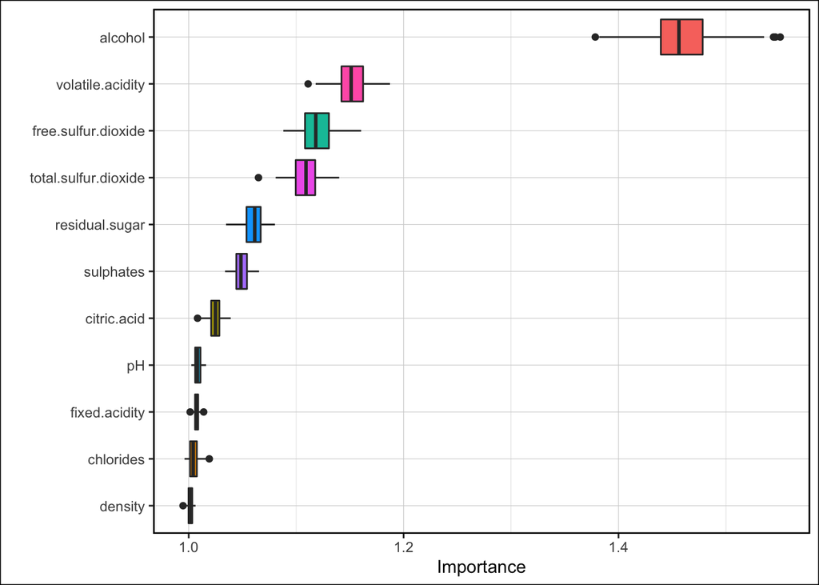

```r
vip(object = permutation_imp, # supply the result of vi_permute()
    num_features = ncol(wine_test) - 1, # tell it how many variables to plot (all)
    mapping = aes(fill = Variable), # pass along arguments to ggplot()
    geom = 'boxplot') # plot boxplots (other options in ?vip)
```

#### Compared to regression coefficients

```r
summary(reg_mod)
```

```
##
## Call:
## lm(formula = quality ~ ., data = wine_train)
##
## Residuals:
##     Min      1Q  Median      3Q     Max
## -3.5014 -0.4661 -0.0418  0.4705  2.9675
##
## Coefficients:
##                        Estimate Std. Error t value Pr(>|t|)
## (Intercept)           6.479e+01  1.297e+01   4.996 6.03e-07 ***
## fixed.acidity         7.323e-02  1.717e-02   4.265 2.03e-05 ***
## volatile.acidity     -1.302e+00  8.553e-02 -15.218  < 2e-16 ***
## citric.acid          -4.306e-02  8.866e-02  -0.486    0.627
## residual.sugar        4.679e-02  5.676e-03   8.244  < 2e-16 ***
## chlorides            -5.217e-01  3.644e-01  -1.432    0.152
## free.sulfur.dioxide   4.929e-03  8.311e-04   5.930 3.22e-09 ***
## total.sulfur.dioxide -2.455e-03  3.100e-04  -7.917 2.95e-15 ***
## density              -6.408e+01  1.323e+01  -4.842 1.32e-06 ***
## pH                    4.854e-01  1.005e-01   4.831 1.40e-06 ***
## sulphates             7.425e-01  8.425e-02   8.813  < 2e-16 ***
## alcohol               2.536e-01  1.831e-02  13.848  < 2e-16 ***
## ---
## Signif. codes:  0 '***' 0.001 '**' 0.01 '*' 0.05 '.' 0.1 ' ' 1
##
## Residual standard error: 0.7356 on 5185 degrees of freedom
## Multiple R-squared:  0.2922, Adjusted R-squared:  0.2907
## F-statistic: 194.6 on 11 and 5185 DF,  p-value: < 2.2e-16
```

#### Compared to permutation importances of the regression model

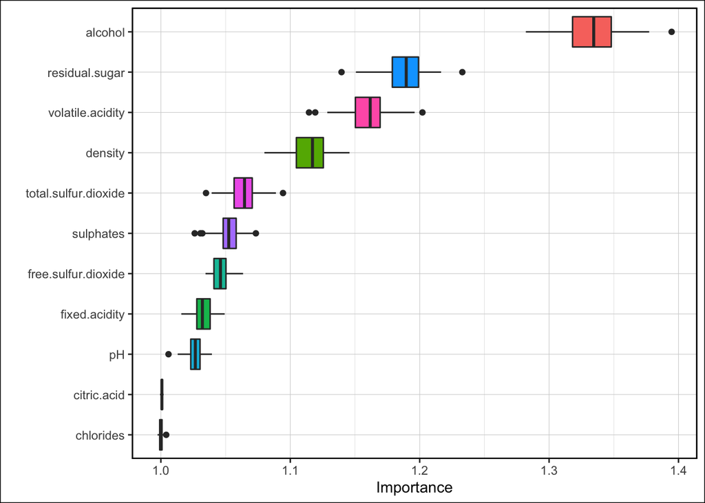

```r
# Same here
vip(object = vi_permute(
  object = reg_mod,
  feature_names = wine_train %>% select(-quality) %>% names,
  train = wine_test,
  target = wine_test$quality,
  metric = 'mse',
  type = 'ratio',
  nsim = 100,
  keep = T,
  pred_wrapper = function(object, newdata) predict(object, newdata)),
  num_features = ncol(wine_test) - 1,
  mapping = aes(fill = Variable),
  geom = 'boxplot'
)
```

# Hyperparameter tuning

#### A quick primer on tuning with `caret`:

1. A model is trained with the `train` function.
2. We use the `trainControl` function to pass along to `train` various options that will guide our hyperparameter tuning process.
3. We also supply to `train` a ‘tune grid’ or ‘hyperparameter grid’, which specifies all of the combinations of hyperparemeter settings to train the model on (of which one will minimize cross validation error and determine the settings of the final model).
4. In the `train` function, we supply our data, the formula of the model, and also instruct `caret` of which model we are using to do the modeling.

Importantly, `caret::train` doesn’t really fit a model itself; it requires us to specify (as an argument supplied to `method`) a model from another `R` package that it knows how to look for. For example, `caret` has in-built codes/names for many of the models built by the many published `R` packages, so that, for example, if we say `method = "rf"`, `caret` knows to build a random forest model by calling (under the hood) `randomForest()` from the package `randomForest`. The list of models available can be found in the `caret::train` documentation. Below, we fit a GBM from the same `gbm` package as above, using `method = "gbm"`.

```r
train_ctrl = trainControl(
  # Set the method for calculating prediction error to be 'cross-validation':
  method = 'cv',
  # Set the number of cross-validation folds to be 5:
  number = 5
)

# Define the values of the hyperparemeters over which to tune the model.
param_grid = expand.grid(
  interaction.depth = c(1, 2, 3),
  n.minobsinnode = c(5, 10),
  shrinkage = c(.1, .8),
  # Note, if we don't supply caret ALL of the hyperparameters it is looking for,
  # we would get an error. So even though we won't tune over multiple values
  # for n.trees, we'll supply it here anyway:
  n.trees = 100 # to save time, I set it to 100 (may want a larger value in practice)
)

# Now run train() with the above settings:
caret_gbm <- caret::train(
  form = quality ~., # supply the formula to model
  data = wine_train, # supply the data
  method = 'gbm', # request a gradient boosted machine
  trControl = train_ctrl,
  tuneGrid = param_grid,
  verbose = F # we don't want it to print out results at every iteration!
)
```

**Let’s look at the output**

```r
caret_gbm
```

```
## Stochastic Gradient Boosting
##
## 5197 samples
##   11 predictor
##
## No pre-processing
## Resampling: Cross-Validated (5 fold)
## Summary of sample sizes: 4157, 4157, 4158, 4158, 4158
## Resampling results across tuning parameters:
##
##   shrinkage  interaction.depth  n.minobsinnode  RMSE       Rsquared   MAE
##   0.1        1                   5              0.7277587  0.3107758  0.5795559
##   0.1        1                  10              0.7282995  0.3101599  0.5795152
##   0.1        2                   5              0.7027605  0.3547411  0.5536905
##   0.1        2                  10              0.7038352  0.3526403  0.5555297
##   0.1        3                   5              0.6946449  0.3681259  0.5462374
##   0.1        3                  10              0.6943401  0.3691544  0.5463812
##   0.8        1                   5              0.7260031  0.3145063  0.5674162
##   0.8        1                  10              0.7242945  0.3163422  0.5672335
##   0.8        2                   5              0.7343802  0.3193877  0.5703222
##   0.8        2                  10              0.7343035  0.3155772  0.5723601
##   0.8        3                   5              0.7557079  0.3089381  0.5894348
##   0.8        3                  10              0.7553857  0.3041155  0.5849650
##
## Tuning parameter 'n.trees' was held constant at a value of 100
## RMSE was used to select the optimal model using the smallest value.
## The final values used for the model were n.trees = 100, interaction.depth =
##  3, shrinkage = 0.1 and n.minobsinnode = 10.
```

**We can also extract this information directly:**

```r
best_params <- caret_gbm$bestTune
best_params
```

```
##   n.trees interaction.depth shrinkage n.minobsinnode
## 6     100                 3       0.1             10
```

**And the best model itself for use with other functions such as `predict` or `vip`**

```r
final_model <- caret_gbm$finalModel
```

#### Finally we can validate our final model’s performance with the test data:

```r
# Using the same functions we used above to retrieve test-set error:
data.frame(
  R2 = R2_Score(
    y_pred = predict(object = final_model,
                     newdata = wine_test,
                     n.trees = best_params$n.trees),
    y_true = wine_test$quality),
  MSE = MSE(
    y_pred = predict(object = final_model,
                     newdata = wine_test,
                     n.trees = best_params$n.trees),
    y_true = wine_test$quality)
)
```

```
##          R2      MSE
## 1 0.3714385 0.478181
```

By trying out different values for the hyperparameters, we found a model that is better at predicting the quality of the held-out data better than the default values did.

# Let's translate it to `python`

This gives us a chance to re-run the analysis in environments that might have `python`, but not `R`, installed. In addition, we can compare the results between the two (more specifically the packages used in each language), which we'll expect to be similar, but not exactly the same due to stochasticity in the analysis or implementation differences.

```python
import numpy as np
import pandas as pd
import matplotlib.pyplot as plt
from sklearn.model_selection import GridSearchCV
import numpy as np
from sklearn.ensemble import GradientBoostingRegressor
from sklearn.inspection import permutation_importance
from sklearn.metrics import r2_score, mean_squared_error
from sklearn.model_selection import train_test_split
```

**Read in the data**

```python
wine_df = pd.read_csv('~/all_wine_quality.csv')
```

**Check the variable names**

```python
wine_df.columns
```

```
## Index(['fixed.acidity', 'volatile.acidity', 'citric.acid', 'residual.sugar',
##        'chlorides', 'free.sulfur.dioxide', 'total.sulfur.dioxide', 'density',
##        'pH', 'sulphates', 'alcohol', 'quality'],
##       dtype='object')
```

Looks like everything ran in as expected.

# As before, we’ll split the data to start

```python
X = wine_df.drop(columns = 'quality') # select all columns except 'quality'
y = wine_df['quality'] # select just quality
X_train, y_train, X_test, y_test = train_test_split(X, y, random_state = 1, test_size = .2)
```

But wait, we already saved out our train and test data! The above is just for demonstration. For **reproducibility**, we’ll actually read in the same exact train and test split of the data that we used and wrote out above.

```python
X_train = pd.read_csv("~/wine_train.csv")
X_test = pd.read_csv("~/wine_test.csv")
# We do need to drop the response from each of the above, and save them as y_*
y_train = X_train.quality # another way to select JUST quality
X_train = X_train.drop(columns = 'quality')
y_test = X_test.quality # another way to select JUST quality
X_test = X_test.drop(columns = 'quality')
# Check the dimensions for sanity
print(X_train.shape)
```

```
## (5197, 11)
```

```python
y_test.shape
```

```
## (1300,)
```

#### A quick primer on hyperparameter tuning in `sklearn`

1. Instantiate the model that you will be tuning. This is your **estimator**. This can be any number of the models built-in to `sklearn`, such as support vector machines, logistic regressions, random forests, neural nets, etc.
2. Instantiate your grid using `GridSearchCV()`. This will take as an argument the grid-like object containing all of the hyperparameter values (specific to the type of estimator) that we would like to assess.
3. Fit the estimator to the grid. Typically, we can use k-fold cross validation with the train data to score model performance for each iteration of the grid.
4. Score the final model to held-out test set. In this step, we take the best iteration, identified in step 3 using only k-fold cross-validation, to externally validate the model that was fit to the best combination of hyperparameteres. This is our final model, and therefore we must use a never-before-seen test set to validate it.

#### Setting up the hyperparameters:

Here we define the parameter grid in the way compatible with the `GridSearchCV` function.  
The parameter grid is going to by a type of `python` object called a `dict` or “dictionary”. It will be nothing more than a character string, paired with a vector of values, then another character string to represent the name of another hyperparemeter, seperated by a `:` from a list of possible values, and so on. Like so:

```python
params = {'n_estimators': [100], # The number of trees to build
          'max_depth': [1, 3], # same as 'interaction depth' (number of splits per tree)
          'min_samples_split': [5, 10], # same as n.minobsinnode (# of samples per leaf)
          'learning_rate': [.1, .8], # same as shrinkage (size of step along gradient)
          'loss': ['ls']} # we will search for the least squared error (same as MSE)
```

#### Setting up the model (estimator)

Now we “instantiate” the model, by running `sklearn`’s own GBM function, but we won’t supply any hyperparameters or data just yet.

```python
GBM = GradientBoostingRegressor(random_state = 1) # setting a seed for reproducibility here as well
```

#### Set up the grid itself

Now we supply our model to `GridSearchCV`, along with the parameters to again instantiate an object, this time a grid-search-cross-validation object. Note, we are just “instantiating” again because we have not supplied data. Here, we supply those options to control the grid search, such as how many folds in our cross-validation tests, the estimator to use, and the parameters over which to tune (that we defined above).

```python
gbm_gridCV = GridSearchCV(estimator = GBM, param_grid = params, cv = 5)
```

Now we have created an object, called `gbm_gridCV`, which contains a model and a parameter grid. It is created with the `sklearn` function `GridSearchCV`, and so it has it’s own functions or `methods` that we can call from it. One is `fit`, which we will finally use to supply the data, and fit each model, as in `caret::train`.

#### Run the search:

```python
gbm_gridCV.fit(X_train, y_train)
```

```
## GridSearchCV(cv=5, estimator=GradientBoostingRegressor(random_state=1),
##              param_grid={'learning_rate': [0.1, 0.8], 'loss': ['ls'],
##                          'max_depth': [1, 3], 'min_samples_split': [5, 10],
##                          'n_estimators': [100]})
```

Note, we didn’t have to save the above line or assign a new object using “`=`”. With the `GridSearchCV` class of objects, it simply updates itself when we run `fit`.

**Now we can view the results from running the grid search cross-validation.**

```python
results_table = gbm_gridCV.cv_results_
# The results table has a lot of info (see the documentation for GridSearchCV)
# We'll extract the hyperparameters values that were used, and the CV score.

pd.DataFrame(results_table)[['param_learning_rate','param_max_depth','param_min_samples_split','mean_test_score']]
```

```
##   param_learning_rate param_max_depth param_min_samples_split  mean_test_score
## 0                 0.1               1                       5         0.296276
## 1                 0.1               1                      10         0.296276
## 2                 0.1               3                       5         0.378865
## 3                 0.1               3                      10         0.379663
## 4                 0.8               1                       5         0.323059
## 5                 0.8               1                      10         0.323059
## 6                 0.8               3                       5         0.297600
## 7                 0.8               3                      10         0.295266
```

Note that `sklearn` created these columns for us automatically, by just prepending the name of each parameter with “param_”. As we can see, the best iteration occurred when the learning rate was set to 0.1, the maximum depth was 3, and the number of samples allowed in a leaf were 10.

**To access these values directly, you can use** `gbm_gridCV.best_params_`

```python
gbm_gridCV.best_params_
```

```
## {'learning_rate': 0.1, 'loss': 'ls', 'max_depth': 3, 'min_samples_split': 10, 'n_estimators': 100}
```

## Score the final model

And as above, we can score our final model with the completely unseen test data. To do so, we can use another function like those above that take the predicted and true values of a given response, to calculate error. Here, when we call the `predict` method directly from the `gbm_gridCV` object that we fit, it will generate predictions automatically from the best model in the grid search based on the mean cross-validation score.

```python
pd.DataFrame({'R2': [r2_score(y_test, gbm_gridCV.predict(X_test))],
              'MSE': [mean_squared_error(y_test, gbm_gridCV.predict(X_test))]})
```

```
##         R2       MSE
## 0  0.39737  0.458453
```

# Variable Importance in `sklearn`

Finally, `sklearn` has the same capacity to generate permutation variable importance that are calculated on held-out test data.

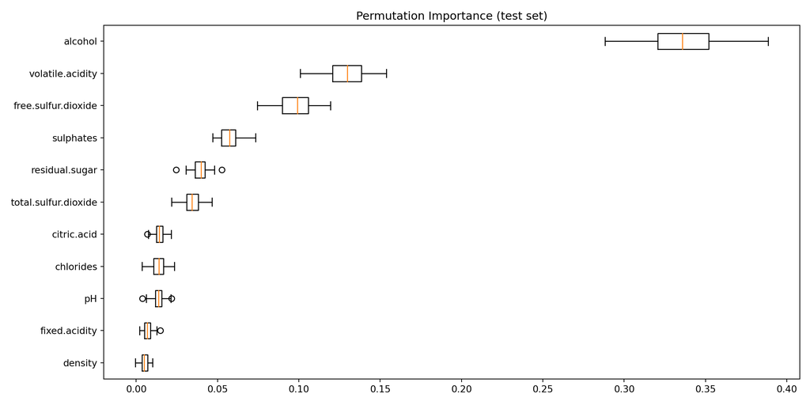

```python
result = permutation_importance(gbm_gridCV.best_estimator_, X_test, y_test, n_repeats=100,
                                random_state=1, n_jobs=2)
sorted_idx = result.importances_mean.argsort()
fig = plt.figure(figsize=(12, 6));
plt.boxplot(result.importances[sorted_idx].T, vert = False,
            labels=np.array(X_test.columns)[sorted_idx]);
plt.title("Permutation Importance (test set)")
fig.tight_layout();
plt.show();
```